# Karlsruhe Is Getting Warmer

A short climate report from 150 years of daily weather data

Author

Published

November 15, 2026

## 1 Introduction

Karlsruhe is one of the warmest cities in Germany. This report uses daily observations of the Deutscher Wetterdienst (Deutscher Wetterdienst 2026) to show how its climate changed since 1876. All analyses were done in R with the tidyverse (Wickham et al. 2023).

## 2 Data

Two stations: Karlsruhe (1876–2008) and its successor Rheinstetten (since 2008). Years with fewer than 360 observed days are excluded, leaving 148 years.

## 3 Results

### 3.1 Temperature

The mean temperature of the last 30 years (1996–2025) is **1.2 °C** higher than in the reference period 1961–1990. The warmest year on record is 2023. Figure 1 shows the deviation of every year from the reference mean, Figure 2 the same data as “warming stripes” (Hawkins 2018).

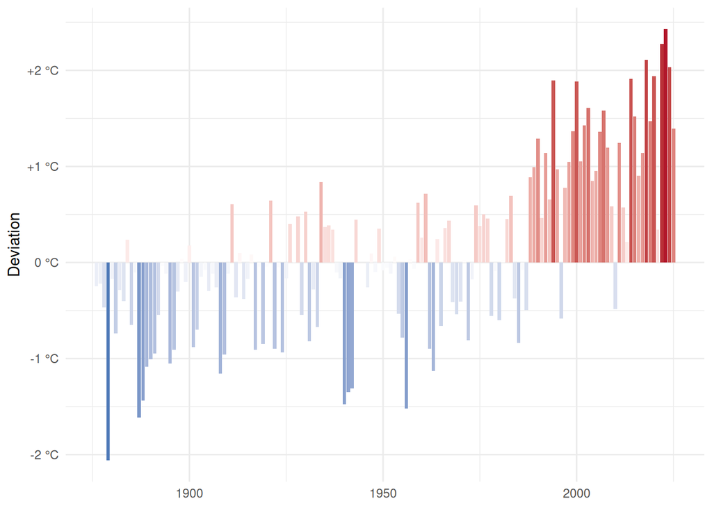

Figure 1: Annual mean temperature in Karlsruhe, deviation from the 1961–1990 mean.

[figure not shown]

Figure 2: Warming stripes for Karlsruhe, one stripe per year.

### 3.2 Hot and frost days

A hot day (*heißer Tag*) has a maximum of at least 30 °C, a frost day a minimum below 0 °C. Table 1 compares both periods.

Table 1: Average number of days per year.

[output not shown]

## 4 Method

The anomaly of year $t$ is its mean temperature minus the mean of the reference period $R$ (30 years):

$$\Delta T_t = \bar{T}_t - \frac{1}{30} \sum_{s \in R} \bar{T}_s$$

## 5 References

Deutscher Wetterdienst. 2026. *Historical Daily Station Observations (Temperature, Pressure, Precipitation, Sunshine Duration, Etc.) for Germany*. Climate Data Center. https://opendata.dwd.de/climate_environment/CDC/observations_germany/climate/daily/kl/historical/.

Hawkins, Ed. 2018. *Warming Stripes*. Climate Lab Book. https://www.climate-lab-book.ac.uk/2018/warming-stripes/.

Wickham, Hadley, Mine Çetinkaya-Rundel, and Garrett Grolemund. 2023. *R for Data Science*. 2nd ed. O’Reilly. https://r4ds.hadley.nz/.